# VA Better Place

Author

Aislin John, Donna Guzman, Dawit Tekeste

Published

October 15, 2023

## Project overview

“VA Better Place” focuses on creating a comprehensive database that assesses the quality of living conditions in different ZIP codes within Virginia. This project aims to provide valuable insights into education, employment, housing, crime activity, transportation, and population data, ultimately aiding residents, policymakers, and researchers in making informed decisions to enhance the overall quality of life in the state.

## Key deliverables:

- [Pitch Video](https://drive.google.com/file/d/1Sikim-ladH6ERmn24CFSi-oMzZA6jGdi/view?usp=sharing)
- [Design Video](https://drive.google.com/file/d/1Igr7PYTEao3p3qTgvx8k_nXHOFsSnmG5/view?usp=sharing)
- [Github Project](https://github.com/cmsc-vcu/cmsc508-fa2023-prj-VA_better_placegroup39)

## Problem Description

**Problem Domain:**

The problem domain of Virginia Better Place revolves around improving the living conditions in different zip codes across the state of Virginia. This encompasses a wide range of aspects including education, housing, employment, crime activity, transportation, and population demographics. To understand this domain, one must consider the unique characteristics, challenges, and opportunities present in each zip code. For instance, some zip codes may have thriving job markets but inadequate public transportation, while others may excel in education but struggle with high crime rates.

**Need:**

The need for the Virginia Better Place database arises from the desire to comprehensively assess living conditions across Virginia. This database aims to provide valuable insights into each zip code, helping policymakers, local governments, researchers, and residents make informed decisions. By centralizing data on education, housing, employment, crime activity, transportation, and population, this database will help identify areas that require improvements, allocate resources more effectively, and create a better quality of life for Virginia residents.

**Context:**

- With how the data mentioned above is scattered all over the internet the goal of this project to put everything in one database so that all teh data for a zip code can be accessed with a single api call or can also do specific queries for each entities attributes

**Scope:**

- The scope of the project encompasses the development and maintenance of a comprehensive database aimed at aggregating and presenting data relevant to living conditions across various counties in Virginia. The database will cover a multitude of aspects including education, housing, employment, crime activity, transportation, and population metrics. It’s designed to be a one-stop resource for individuals seeking to explore and analyze living conditions in Virginia, whether for short-term or permanent relocation. The scope extends to providing an accessible and user-friendly interface for querying this data, as well as ensuring the data is well-organized, up-to-date, and reliable.

**Perspective:**

- **End User:** The database serves as an invaluable tool for making informed decisions regarding relocation. They can easily compare different zip codes based on their preferences such as rent prices, bike routes, and safety, among other criteria. The project simplifies the research process by aggregating all necessary data into one platform, saving time and ensuring they have all the information needed to make a well-informed decision.
- **Developer:** From a developer’s standpoint, the project requires a robust backend database system to handle a variety of data types and queries efficiently. It also necessitates a front-end interface that is intuitive and user-friendly. There’s a continuous need for data updates, monitoring, and possibly expanding the database to encompass more data or cover additional areas over time.

**User Roles and Use Cases:**

- **Policymakers:** These users may need access to various data points to inform policies related to education, public transportation, or crime reduction.
- **Researchers:** Researchers might perform data analysis, studying correlations between different living conditions.
- **Residents:** Residents could use the database to compare zip codes when considering a new home or assessing the safety of a neighborhood.
- **Community Organizations:** Non-profit organizations could use the data to target their assistance and outreach programs effectively.

Overall, the Virginia Better Place database will serve as a valuable tool for understanding and improving the living conditions in Virginia, benefiting a wide range of users and helping to address the unique challenges in different zip codes.

## Database design

**Entity-relationship diagram (ERD)**

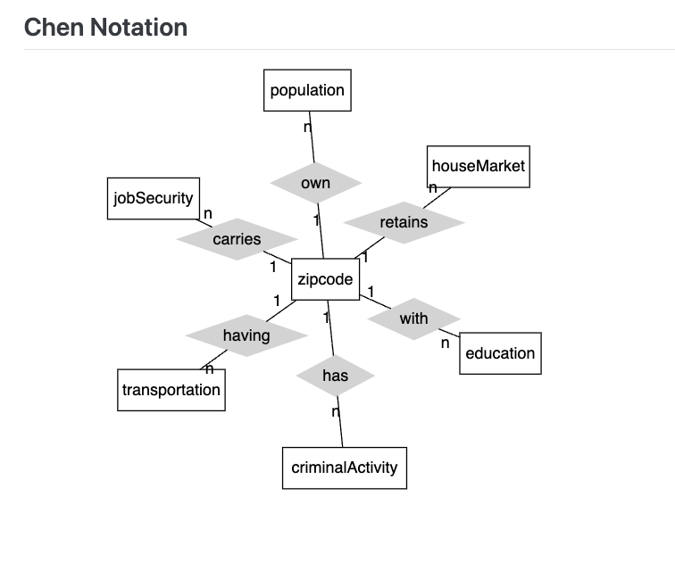

Chen Notation for Virginia Better Place Database

### Crow’s Foot Diagram

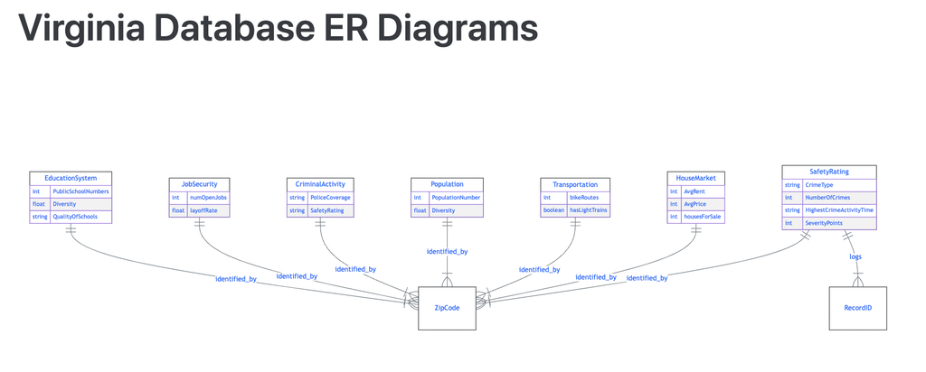

Crows Foot Ful Diagram

**Specific queries**

1. `SELECT ZipCode, PublicSchoolNumbers FROM EducationSystem WHERE QualityOfSchools IS NOT NULL;`
2. `SELECT ZipCode, SafetyRating FROM CriminalActivity WHERE PoliceCoverage = 'A';`
3. `SELECT ZipCode, CrimeType FROM SafetyRating WHERE NumberofCrimes > 10;`
4. `SELECT ZipCode, PopulationNumber FROM Population WHERE Diversity < 40%;`
5. `SELECT ZipCode FROM Transportation WHERE bikeRoutes > 10 AND hasLightTrains = TRUE;`
6. `SELECT ZipCode, AvgRent, AvgPrice FROM HouseMarket WHERE AvgRent < 1000;`
7. `SELECT ZipCode, numOpenJobs FROM JobSecurity WHERE layoffRate < 12%;`
8. `SELECT ZipCode FROM EducationSystem WHERE Diversity > 50%;`
9. `SELECT ZipCode FROM CriminalActivity WHERE SafetyRating = 'A' AND PoliceCoverage = 'B';`
10. `SELECT DISTINCT sr.ZipCode FROM SafetyRating sr JOIN Population p ON sr.ZipCode = p.ZipCode WHERE p.Diversity > 50% AND sr.CrimeType = 'Shoplifting';`
11. `SELECT ZipCode, housesForSale FROM HouseMarket WHERE AvgPrice > 500000;`
12. `SELECT ZipCode FROM Transportation WHERE bikeRoutes < 5 AND hasLightTrains = FALSE;`
13. `SELECT ZipCode FROM Population WHERE PopulationNumber > 50000 AND Diversity < 40%;`
14. `SELECT sr.ZipCode, sr.CrimeType, ca.SafetyRating FROM SafetyRating sr JOIN CriminalActivity ca ON sr.ZipCode = ca.ZipCode WHERE sr.NumberofCrimes > 50;`
15. `SELECT ZipCode FROM HouseMarket WHERE AvgRent BETWEEN 1000 AND 1300;`
16. `SELECT ZipCode, Diversity FROM EducationSystem WHERE PublicSchoolNumbers < 50;`
17. `SELECT ZipCode, hasLightTrains FROM Transportation WHERE bikeRoutes > 8;`
18. `SELECT ZipCode, layoffRate FROM JobSecurity WHERE numOpenJobs < 80;`
19. `SELECT h.ZipCode FROM HouseMarket h JOIN JobSecurity j ON h.ZipCode = j.ZipCode WHERE j.layoffRate > 10% AND h.AvgRent < 1000;`
20. `SELECT e.ZipCode FROM EducationSystem e JOIN Population p ON e.ZipCode = p.ZipCode WHERE e.Diversity < 40% AND p.Diversity > 60%;`

## Functional Dependencies and Normalization

1. EducationSystem Table:

   ```
    ZipCode -> PublicSchoolNumbers<br>
    ZipCode -> QualityOfSchools<br>
    ZipCode -> Diversity<br>
   ```

   ```
    RecordID -> SafetyRating<br>
    RecordID -> NumberofCrimes<br>
    RecordID -> CrimeType<br>
   ```

3. Population Table:

   ```
    ZipCode -> PopulationNumber<br>
    ZipCode -> Diversity<br>
   ```

4. Transportation Table:

   ```
    ZipCode -> bikeRoutes<br>
    ZipCode -> hasLightTrains<br>
   ```

5. HouseMarket Table:

   ```
    ZipCode -> AvgRent<br>
    ZipCode -> AvgPrice<br>
    ZipCode -> housesForSale<br>
   ```

6. JobSecurity Table:

   ```
    ZipCode -> numOpenJobs<br>
    ZipCode -> layoffRate<br>
   ```

Forth Normal Form (4NF)

- Decompose multi-valued attributes like safety Rating and decomposing the values needed to calculate for the table other than that the other tables are **4NF** form

## Project management

**Draft Project schedule**

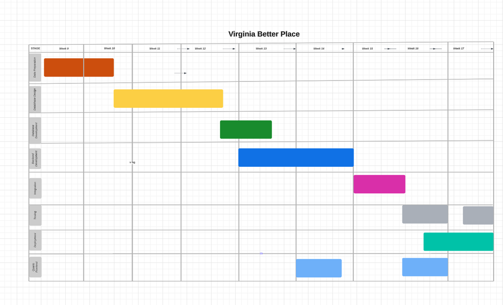

GAANT Graph